# CM3015: Machine Learning and Neural Networks

# Removal of Layers:

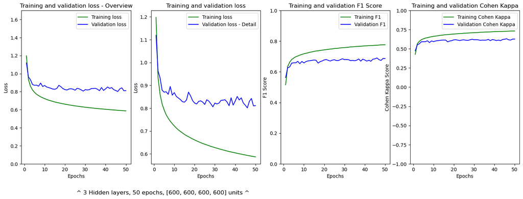

```python
stage_6_hyperparameters = {
            #a tensorflow warning suggested using the legacy version of M1/M2 chips
            "optimizer": tf.keras.optimizers.legacy.RMSprop(decay=1e-3), #tweaked the rate of decay to best suit this trial
            "learning_rate": None,
            "batch_size": 128,
            "epochs_number": 50,
            "loss_function": 'categorical_crossentropy'
        }


stage_6_layers = [
        layers.Dense(600, activation='relu', input_shape=(9,)), #input shape == x_train_tensor[0].shape
        layers.Dense(600, activation='relu'),
        layers.Dense(600, activation='relu'),
        layers.Dense(600, activation='relu'),
        layers.Dense(num_classes, activation='softmax') #7 output neurons as there are 7 classes
        ]

model_2_hidden_layers = NeuralNet(stage_6_layers)
model_2_hidden_layers.set_hyperparameters(stage_6_hyperparameters)
model_2_hidden_layers.compile_model()
model_2_hidden_layers.fit(x_train_scaled, y_train, (x_val_scaled, y_val), verboseParam=0)
```

### Looking at the graph above (second column), removing 1 Layer did not appear to make any significant reductions in overfitting.

# Adding Dropout Layers:

I added drop out layers after every hidden layer:

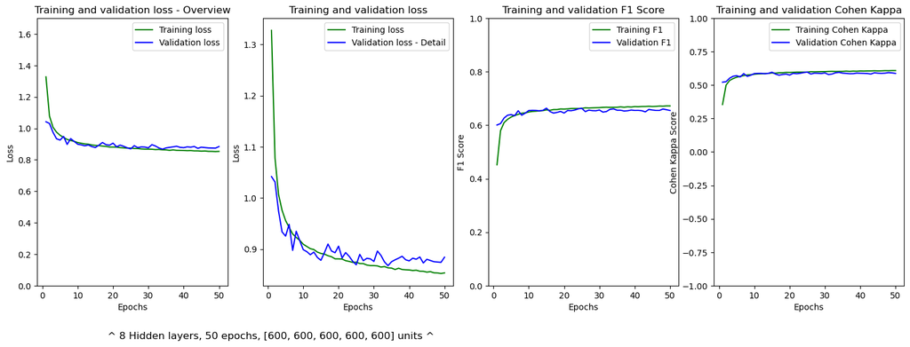

```python
stage_6_hyperparameters = {
            #a tensorflow warning suggested using the legacy version of M1/M2 chips
            "optimizer": tf.keras.optimizers.legacy.RMSprop(decay=1e-3), #tweaked the rate of decay to best suit this trial
            "learning_rate": None,
            "batch_size": 128,
            "epochs_number": 50,
            "loss_function": 'categorical_crossentropy'
        }


stage_6_layers = [
        layers.Dense(stage_6_num_units, activation='relu', input_shape=(9,)), #input shape == x_train_tensor[0].shape
        layers.Dense(stage_6_num_units, activation='relu', bias_regularizer=regularizers.L1(1e-6)),
        layers.Dropout(0.6),
        layers.Dense(stage_6_num_units, activation='relu', bias_regularizer=regularizers.L1(1e-6)),
        layers.Dropout(0.6),
        layers.Dense(stage_6_num_units, bias_regularizer=regularizers.L1(1e-6)),
        layers.Dropout(0.4),
        layers.Dense(stage_6_num_units, bias_regularizer=regularizers.L1(1e-6)),
        layers.Dropout(0.4),
        layers.Dense(num_classes, activation='softmax') #7 output neurons as there are 7 classes
        ]

model_2_hidden_layers = NeuralNet(stage_6_layers)
model_2_hidden_layers.set_hyperparameters(stage_6_hyperparameters)
model_2_hidden_layers.compile_model()
model_2_hidden_layers.fit(x_train_scaled, y_train, (x_val_scaled, y_val), verboseParam=0)
```

#### The training/validation loss curve above shows a considerable improvement ; there is no longer a sizeable gap between training and validation loss.

## Weight initialisation:

He initialization is commonly used with relu activation functions (Katanforoosh, 2019): I conducted the following experiments with He initialization:  
Keras offers 2 forms of He initialization: HeNormal and HeUniform

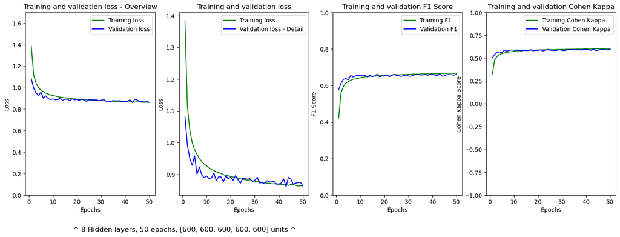

```python
from keras import initializers
stage_6_hyperparameters = {
            #a tensorflow warning suggested using the legacy version of M1/M2 chips
            "optimizer": tf.keras.optimizers.legacy.RMSprop(decay=1e-3), #tweaked the rate of decay to best suit this trial
            "learning_rate": None,
            "batch_size": 128,
            "epochs_number": 50,
            "loss_function": 'categorical_crossentropy'
        }


stage_6_layers = [
        layers.Dense(stage_6_num_units, activation='relu', input_shape=(9,)), #input shape == x_train_tensor[0].shape
        layers.Dense(stage_6_num_units, activation='relu', bias_regularizer=regularizers.L1(1e-6),
                     kernel_initializer=initializers.HeNormal()),
        layers.Dropout(0.6),
        layers.Dense(stage_6_num_units, activation='relu', bias_regularizer=regularizers.L1(1e-6),
                     kernel_initializer=initializers.HeNormal()),
        layers.Dropout(0.6),
        layers.Dense(stage_6_num_units, bias_regularizer=regularizers.L1(1e-6),
                     kernel_initializer=initializers.HeNormal()),
        layers.Dropout(0.4),
        layers.Dense(stage_6_num_units, bias_regularizer=regularizers.L1(1e-6),
                    kernel_initializer=initializers.HeNormal()),
        layers.Dropout(0.4),
        layers.Dense(num_classes, activation='softmax') #7 output neurons as there are 7 classes
        ]

model_dropout = NeuralNet(stage_6_layers)
model_dropout.set_hyperparameters(stage_6_hyperparameters)
model_dropout.compile_model()
model_dropout.fit(x_train_scaled, y_train, (x_val_scaled, y_val), verboseParam=0)
```

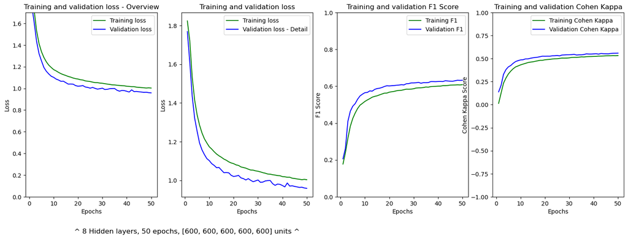

```python
stage_6_layers = [
        layers.Dense(stage_6_num_units, activation='relu', input_shape=(9,)), #input shape == x_train_tensor[0].shape
        layers.Dense(stage_6_num_units, activation='relu', bias_regularizer=regularizers.L1(1e-6),
                     kernel_initializer=initializers.HeUniform()),
        layers.Dropout(0.6),
        layers.Dense(stage_6_num_units, activation='relu', bias_regularizer=regularizers.L1(1e-6),
                     kernel_initializer=initializers.HeUniform()),
        layers.Dropout(0.6),
        layers.Dense(stage_6_num_units, bias_regularizer=regularizers.L1(1e-6),
                     kernel_initializer=initializers.HeUniform()),
        layers.Dropout(0.4),
        layers.Dense(stage_6_num_units, bias_regularizer=regularizers.L1(1e-6),
                    kernel_initializer=initializers.HeUniform()),
        layers.Dropout(0.4),
        layers.Dense(num_classes, activation='softmax') #7 output neurons as there are 7 classes
        ]

model_dropout = NeuralNet(stage_6_layers)
model_dropout.set_hyperparameters(stage_6_hyperparameters)
model_dropout.compile_model()
model_dropout.fit(x_train_scaled, y_train, (x_val_scaled, y_val), verboseParam=0)
```

#### Comparing the 2 rows of graphs above ; the model initialized using HeNormal acheived a lower training and validation loss. I will use HeNormal initialization in the next set of experiments.

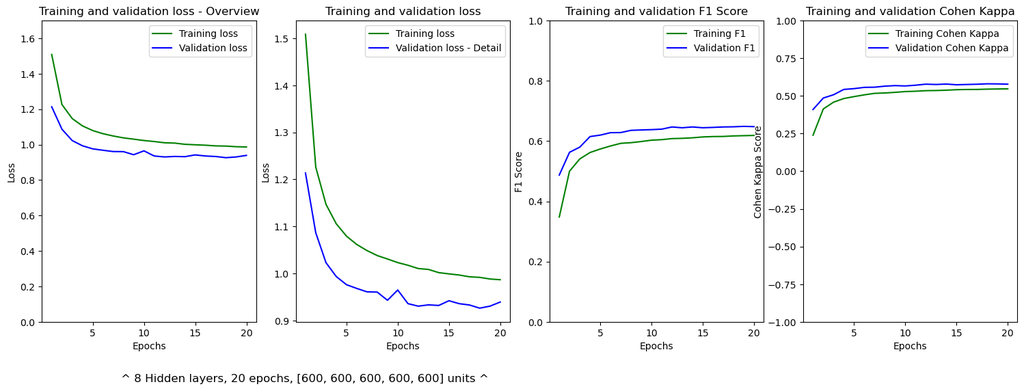

```python
stage_6_hyperparameters = {
            #a tensorflow warning suggested using the legacy version of M1/M2 chips
            "optimizer": tf.keras.optimizers.legacy.RMSprop(decay=1e-3), #tweaked the rate of decay to best suit this trial
            "learning_rate": None,
            "batch_size": 128,
            "epochs_number": 20,
            "loss_function": 'categorical_crossentropy'
        }

stage_6_layers = [
        layers.Dense(stage_6_num_units, activation='relu', input_shape=(9,)), #input shape == x_train_tensor[0].shape
        layers.Dense(stage_6_num_units, activation='relu', bias_regularizer=regularizers.L1(1e-6),
                     kernel_initializer=initializers.HeUniform()),
        layers.Dropout(0.8),
        layers.Dense(stage_6_num_units, activation='relu', bias_regularizer=regularizers.L1(1e-6),
                     kernel_initializer=initializers.HeUniform()),
        layers.Dropout(0.6),
        layers.Dense(stage_6_num_units, bias_regularizer=regularizers.L1(1e-6),
                     kernel_initializer=initializers.HeUniform()),
        layers.Dropout(0.6),
        layers.Dense(stage_6_num_units, bias_regularizer=regularizers.L1(1e-6),
                    kernel_initializer=initializers.HeUniform()),
        layers.Dropout(0.4),
        layers.Dense(num_classes, activation='softmax') #7 output neurons as there are 7 classes
        ]

model_dropout = NeuralNet(stage_6_layers)
model_dropout.set_hyperparameters(stage_6_hyperparameters)
model_dropout.compile_model()
model_dropout.fit(x_train_scaled, y_train, (x_val_scaled, y_val), verboseParam=0)
```

# Change activation function to Exponential Linear Units (ELU):

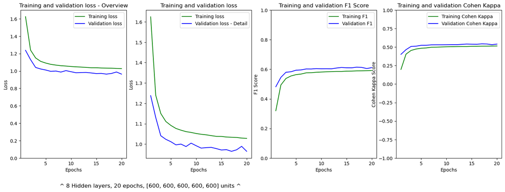

```python
from keras import initializers
stage_6_hyperparameters = {
            #a tensorflow warning suggested using the legacy version of M1/M2 chips
            "optimizer": tf.keras.optimizers.legacy.RMSprop(decay=1e-3), #tweaked the rate of decay to best suit this trial
            "learning_rate": None,
            "batch_size": 128,
            "epochs_number": 20,
            "loss_function": 'categorical_crossentropy'
        }


stage_6_layers = [
        layers.Dense(stage_6_num_units, activation='elu', input_shape=(9,)), #input shape == x_train_tensor[0].shape
        layers.Dense(stage_6_num_units, activation='elu', bias_regularizer=regularizers.L1(1e-6),
                     kernel_initializer=initializers.HeNormal()),
        layers.Dropout(0.8),
        layers.Dense(stage_6_num_units, activation='elu', bias_regularizer=regularizers.L1(1e-6),
                     kernel_initializer=initializers.HeNormal()),
        layers.Dropout(0.6),
        layers.Dense(stage_6_num_units, activation='elu', bias_regularizer=regularizers.L1(1e-6),
                     kernel_initializer=initializers.HeNormal()),
        layers.Dropout(0.6),
        layers.Dense(stage_6_num_units, activation='elu', bias_regularizer=regularizers.L1(1e-6),
                    kernel_initializer=initializers.HeNormal()),
        layers.Dropout(0.4),
        layers.Dense(num_classes, activation='softmax') #7 output neurons as there are 7 classes
        ]

model_dropout = NeuralNet(stage_6_layers)
model_dropout.set_hyperparameters(stage_6_hyperparameters)
model_dropout.compile_model()
model_dropout.fit(x_train_scaled, y_train, (x_val_scaled, y_val), verboseParam=0)
```

The loss appears to have increased from 0.9-1.0 after change 'relu' to 'elu'.

# Change optimization function to ADAM variants:

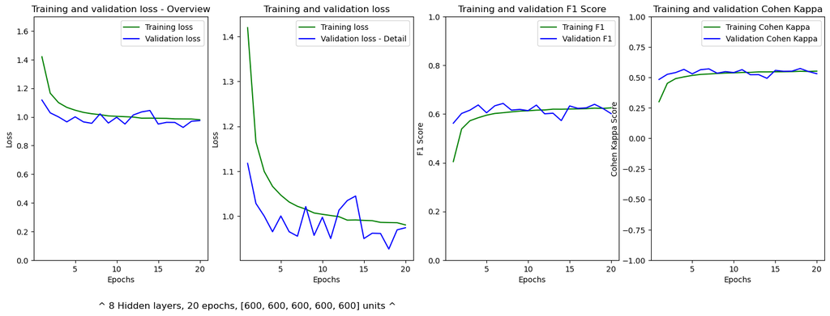

```python
from keras import initializers
stage_6_hyperparameters = {
            #a tensorflow warning suggested using the legacy version of M1/M2 chips
            "optimizer": tf.keras.optimizers.legacy.Nadam(decay=1e-3), #tweaked the rate of decay to best suit this trial
            "learning_rate": None,
            "batch_size": 128,
            "epochs_number": 20,
            "loss_function": 'categorical_crossentropy'
        }


stage_6_layers = [
        layers.Dense(stage_6_num_units, activation='relu', input_shape=(9,)), #input shape == x_train_tensor[0].shape
        layers.Dense(stage_6_num_units, activation='relu', bias_regularizer=regularizers.L1(1e-6),
                     kernel_initializer=initializers.HeNormal()),
        layers.Dropout(0.6),
        layers.Dense(stage_6_num_units, activation='relu', bias_regularizer=regularizers.L1(1e-6),
                     kernel_initializer=initializers.HeNormal()),
        layers.Dropout(0.6),
        layers.Dense(stage_6_num_units, bias_regularizer=regularizers.L1(1e-6),
                     kernel_initializer=initializers.HeNormal()),
        layers.Dropout(0.4),
        layers.Dense(stage_6_num_units, bias_regularizer=regularizers.L1(1e-6),
                    kernel_initializer=initializers.HeNormal()),
        layers.Dropout(0.4),
        layers.Dense(num_classes, activation='softmax') #7 output neurons as there are 7 classes
        ]

model_nadam = NeuralNet(stage_6_layers)
model_nadam.set_hyperparameters(stage_6_hyperparameters)
model_nadam.compile_model()
model_nadam.fit(x_train_scaled, y_train, (x_val_scaled, y_val), verboseParam=0)
```

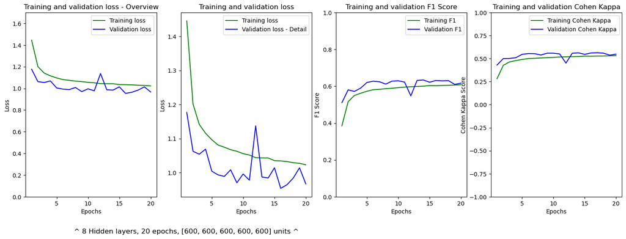

```python
from keras import initializers
stage_6_hyperparameters = {
            #a tensorflow warning suggested using the legacy version of M1/M2 chips
            "optimizer": tf.keras.optimizers.legacy.Adam(decay=1e-6), #tweaked the rate of decay to best suit this trial
            "learning_rate": None,
            "batch_size": 128,
            "epochs_number": 20,
            "loss_function": 'categorical_crossentropy'
        }


stage_6_layers = [
        layers.Dense(stage_6_num_units, activation='relu', input_shape=(9,)), #input shape == x_train_tensor[0].shape
        layers.Dense(stage_6_num_units, activation='relu', bias_regularizer=regularizers.L1(1e-6),
                     kernel_initializer=initializers.HeNormal()),
        layers.Dropout(0.6),
        layers.Dense(stage_6_num_units, activation='relu', bias_regularizer=regularizers.L1(1e-6),
                     kernel_initializer=initializers.HeNormal()),
        layers.Dropout(0.6),
        layers.Dense(stage_6_num_units, bias_regularizer=regularizers.L1(1e-6),
                     kernel_initializer=initializers.HeNormal()),
        layers.Dropout(0.4),
        layers.Dense(stage_6_num_units, bias_regularizer=regularizers.L1(1e-6),
                    kernel_initializer=initializers.HeNormal()),
        layers.Dropout(0.4),
        layers.Dense(num_classes, activation='softmax') #7 output neurons as there are 7 classes
        ]

model_nadam = NeuralNet(stage_6_layers)
model_nadam.set_hyperparameters(stage_6_hyperparameters)
model_nadam.compile_model()
model_nadam.fit(x_train_scaled, y_train, (x_val_scaled, y_val), verboseParam=0)
```

Changing the optimizer to Adam and Nadam has not furhter decreased training/validation loss.

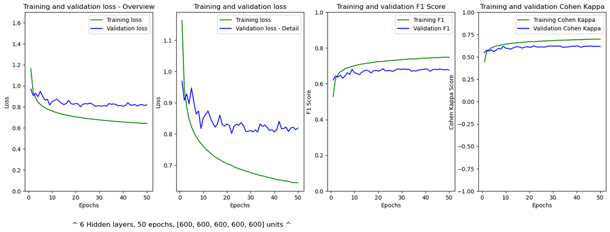

```python
from keras import initializers
stage_6_hyperparameters = {
            #a tensorflow warning suggested using the legacy version of M1/M2 chips
            "optimizer": tf.keras.optimizers.legacy.Adam(decay=1e-3), #tweaked the rate of decay to best suit this trial
            "learning_rate": None,
            "batch_size": 128,
            "epochs_number": 50,
            "loss_function": 'categorical_crossentropy'
        }


stage_6_layers = [
        layers.Dense(stage_6_num_units, activation='relu', input_shape=(9,)), #input shape == x_train_tensor[0].shape
        layers.Dense(stage_6_num_units, activation='relu', bias_regularizer=regularizers.L1(1e-6),
                     kernel_initializer=initializers.HeNormal()),
        layers.Dropout(0.2),
        layers.Dense(stage_6_num_units, activation='relu', bias_regularizer=regularizers.L1(1e-6),
                     kernel_initializer=initializers.HeNormal()),
        layers.Dense(stage_6_num_units, bias_regularizer=regularizers.L1(1e-6),
                     kernel_initializer=initializers.HeNormal()),
        layers.Dense(stage_6_num_units, bias_regularizer=regularizers.L1(1e-6),
                    kernel_initializer=initializers.HeNormal()),
        layers.Dropout(0.2),
        layers.Dense(num_classes, activation='softmax') #7 output neurons as there are 7 classes
        ]

model_nadam = NeuralNet(stage_6_layers)
model_nadam.set_hyperparameters(stage_6_hyperparameters)
model_nadam.compile_model()
model_nadam.fit(x_train_scaled, y_train, (x_val_scaled, y_val), verboseParam=0)
```

# Best model so far:

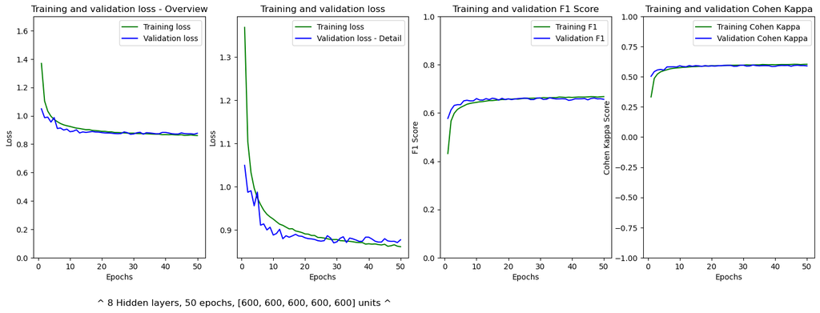

```python
from keras import initializers, regularizers
stage_6_hyperparameters = {
            #a tensorflow warning suggested using the legacy version of M1/M2 chips
            "optimizer": tf.keras.optimizers.legacy.RMSprop(decay=1e-3), #tweaked the rate of decay to best suit this trial
            "learning_rate": None,
            "batch_size": 128,
            "epochs_number": 50,
            "loss_function": 'categorical_crossentropy'
        }


stage_6_layers = [
        layers.Dense(stage_6_num_units, activation='relu', input_shape=(9,)), #input shape == x_train_tensor[0].shape
        layers.Dense(stage_6_num_units, activation='relu', bias_regularizer=regularizers.L1(1e-6),
                     kernel_initializer=initializers.HeNormal()),
        layers.Dropout(0.6),
        layers.Dense(stage_6_num_units, activation='relu', bias_regularizer=regularizers.L1(1e-6),
                     kernel_initializer=initializers.HeNormal()),
        layers.Dropout(0.6),
        layers.Dense(stage_6_num_units, bias_regularizer=regularizers.L1(1e-6),
                     kernel_initializer=initializers.HeNormal()),
        layers.Dropout(0.4),
        layers.Dense(stage_6_num_units, bias_regularizer=regularizers.L1(1e-6),
                    kernel_initializer=initializers.HeNormal()),
        layers.Dropout(0.4),
        layers.Dense(num_classes, activation='softmax') #7 output neurons as there are 7 classes
        ]

model_dropout_4 = NeuralNet(stage_6_layers)
model_dropout_4.set_hyperparameters(stage_6_hyperparameters)
model_dropout_4.compile_model()
model_dropout_4.fit(x_train_scaled, y_train, (x_val_scaled, y_val), verboseParam=0)
```

There appears to be little improvement in the training/validation loss and evaluation metrics after 30 epochs - this seems to be the ideal number of epochs for this set of hyperparameters.

Reflecting on the previous iterations of hyperparamter training - it seemed that the training/validation loss, F1 score and Cohen Kappa were relatively stagnant at ~0.9, ~0.6 and ~0.5. I turned my research to identify more effective methods of searching the hyperparameter space

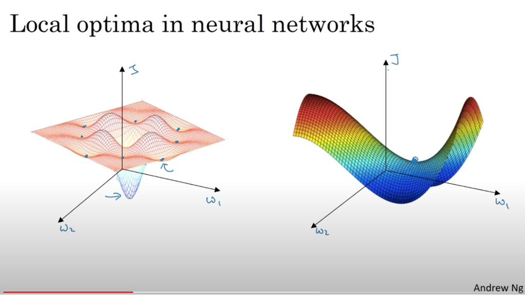

```python
from IPython.display import Image
Image(filename="./images/saddle_local_optima.png", width='400')
```

Image source: (DeepLearningAI & Andrew, 2017)  
A Presentation by Andrew Ng on the DeepLearningAI Youtube Channel discussed that most points of zero gradient are not local optima (as pictured on the left) but are 'saddle' points (pictured on the right) Andrew Ng presents that plateaus are regions in which the derivative is close to 0 for a long time - this can slow down learning;

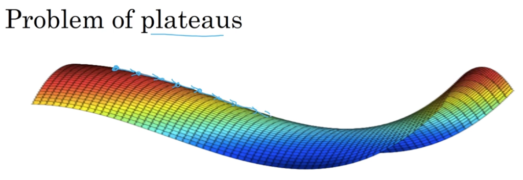

```python
from IPython.display import Image
Image(filename="./images/Plateaus.png", width='400')
```

Image source: (DeepLearningAI & Andrew, 2017)  
This may be the underlying cause of the performance plateau at F1 ~0.6 and Cohen Kappa ~0.5

# Keras Tuner:

The keras_tuner module offers the facility to tune hyperparameters using Bayesian search ; Keras also offers random search, however Bayesian search uses the results of the previous hyperparameter sample to inform the next sampling. This suggests that Bayesian search may be offer more insightful results in less computation time.

```python
from keras import regularizers, initializers
import tensorflow as tf

def build_model(hp):
    neurons_1 = hp.Int("units1", min_value=30, max_value=650, step=10)
    neurons_2 = hp.Int("units2", min_value=30, max_value=650, step=10)
    neurons_3 = hp.Int("units3", min_value=30, max_value=650, step=10)
    neurons_4 = hp.Int("units4", min_value=30, max_value=650, step=10)
    neurons_5 = hp.Int("units5", min_value=100, max_value=650, step=10)
    dropout_1 = hp.Float("dropout1", min_value=0, max_value=1, step=0.2)
    dropout_2 = hp.Float("dropout2", min_value=0, max_value=1, step=0.2)
    dropout_3 = hp.Float("dropout3", min_value=0, max_value=1, step=0.2)
    dropout_4 = hp.Float("dropout4", min_value=0, max_value=1, step=0.2)
    lr = hp.Float("learning_rate", min_value=1e-4, max_value=1e-2, sampling="log")
    alpha = hp.Float("alpha", min_value=1e-4, max_value=1e-2, sampling="log")

    stage_6_hyperparameters = {
            #a tensorflow warning suggested using the legacy version of M1/M2 chips
            "optimizer": tf.keras.optimizers.legacy.RMSprop(decay=1e-3, learning_rate=lr), #tweaked the rate of decay to best suit this trial
            "learning_rate": None,
            "batch_size": 128,
            "epochs_number": 10,
            "loss_function": 'categorical_crossentropy'
        }


    stage_6_layers = [
        layers.Dense(neurons_1, activation='relu', input_shape=(9,)), #input shape == x_train_tensor[0].shape
        layers.Dense(neurons_2, activation='relu', bias_regularizer=regularizers.L1(alpha),
                     kernel_initializer=initializers.HeNormal()),
        layers.Dropout(dropout_1),
        layers.Dense(neurons_3, activation='relu', bias_regularizer=regularizers.L1(alpha),
                     kernel_initializer=initializers.HeNormal()),
        layers.Dropout(dropout_2),
        layers.Dense(neurons_4, bias_regularizer=regularizers.L1(alpha),
                     kernel_initializer=initializers.HeNormal()),
        layers.Dropout(dropout_3),
        layers.Dense(neurons_5, bias_regularizer=regularizers.L1(alpha),
                    kernel_initializer=initializers.HeNormal()),
        layers.Dropout(dropout_4),
        layers.Dense(num_classes, activation='softmax') #7 output neurons as there are 7 classes
        ]

    model = NeuralNet(stage_6_layers)
    model.set_hyperparameters(stage_6_hyperparameters)
    model.compile_model()
    #the use of .model is due to the use of custom class NeuralNet
    return model.model
```

```python
import keras_tuner as kt
tuner = kt.BayesianOptimization(build_model, objective='val_loss', max_trials=10, overwrite=True)
```

```python
tuner.search(x_train_scaled, y_train, epochs=10, validation_data=(x_val_scaled, y_val), batch_size=32)
best_models = tuner.get_best_models()
best_model = best_models[0]
```

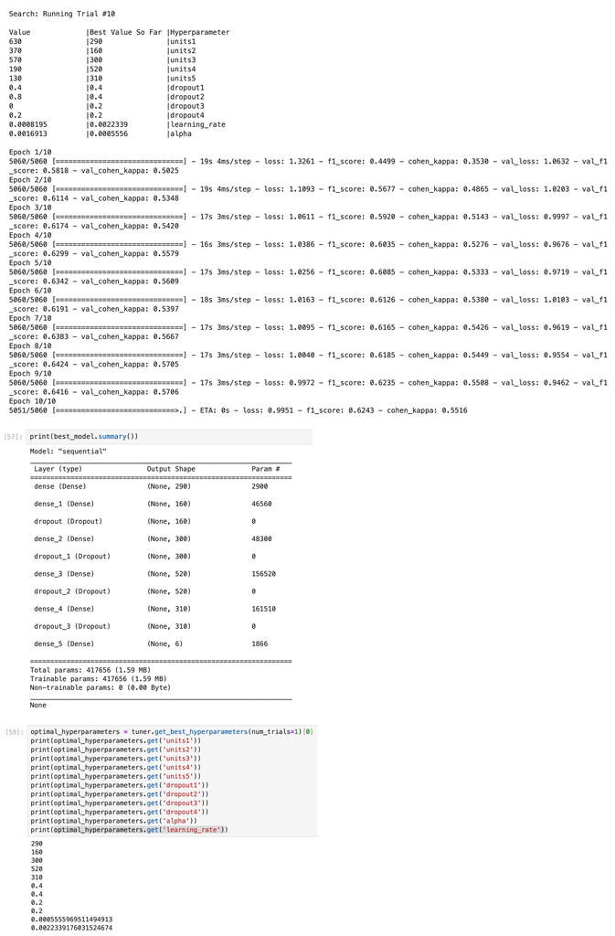

```python
from IPython.display import Image
Image(filename="./images/keras_tuner_2.png", width='500')
```

I then trained this model for 50 epochs in order to get a better overivew of it's capabilities:

```python
from keras import initializers
stage_6_hyperparameters = {
            #a tensorflow warning suggested using the legacy version of M1/M2 chips
            "optimizer": tf.keras.optimizers.legacy.RMSprop(learning_rate=optimal_hyperparameters.get('learning_rate')),
            "learning_rate": None,
            "batch_size": 128,
            "epochs_number": 50,
            "loss_function": 'categorical_crossentropy'
        }


stage_6_layers = [
        layers.Dense(optimal_hyperparameters.get('units1'), activation='relu', input_shape=(9,)), #input shape == x_train_tensor[0].shape
        layers.Dense(optimal_hyperparameters.get('units2'), activation='relu', bias_regularizer=regularizers.L1(optimal_hyperparameters.get('alpha')),
                     kernel_initializer=initializers.HeNormal()),
        layers.Dropout(optimal_hyperparameters.get('dropout1')),
        layers.Dense(optimal_hyperparameters.get('units3'), activation='relu', bias_regularizer=regularizers.L1(optimal_hyperparameters.get('alpha')),
                     kernel_initializer=initializers.HeNormal()),
        layers.Dropout(optimal_hyperparameters.get('dropout2')),
        layers.Dense(optimal_hyperparameters.get('units4'), bias_regularizer=regularizers.L1(optimal_hyperparameters.get('alpha')),
                     kernel_initializer=initializers.HeNormal()),
        layers.Dropout(optimal_hyperparameters.get('dropout3')),
        layers.Dense(optimal_hyperparameters.get('units5'), bias_regularizer=regularizers.L1(optimal_hyperparameters.get('alpha')),
                    kernel_initializer=initializers.HeNormal()),
        layers.Dropout(optimal_hyperparameters.get('dropout4')),
        layers.Dense(num_classes, activation='softmax') #7 output neurons as there are 7 classes
        ]

keras_tuner_2 = NeuralNet(stage_6_layers)
keras_tuner_2.set_hyperparameters(stage_6_hyperparameters)
keras_tuner_2.compile_model()
keras_tuner_2.fit(x_train_scaled, y_train, (x_val_scaled, y_val), verboseParam=0)
```

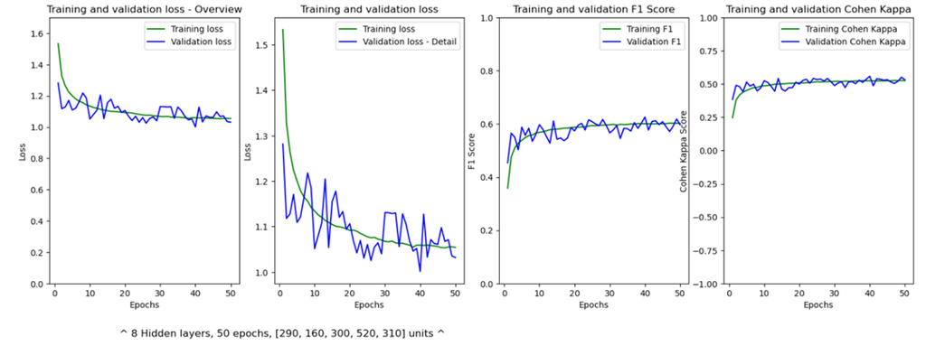

```python
from IPython.display import Image
Image(filename="./images/keras_tuner_2_graph.png", width='500')
```

# Retrain and testing of final model

#### Merge the validation and training sets, retrain for optimal epochs and evaluate on the test set:

```python
x_train_entirety = tf.concat([x_train_scaled, x_val_scaled], axis=0)
y_train_entirety = tf.concat([y_train, y_val], axis=0)
```

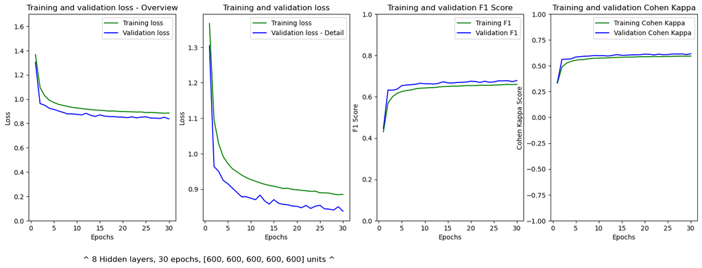

```python
stage_6_hyperparameters = {
            #a tensorflow warning suggested using the legacy version of M1/M2 chips
            "optimizer": tf.keras.optimizers.legacy.RMSprop(decay=1e-3),
            "batch_size": 128,
            "epochs_number": 30,
            "loss_function": 'categorical_crossentropy'
        }


stage_6_layers = [
        layers.Dense(stage_6_num_units, activation='relu', input_shape=(9,)), #input shape == x_train_tensor[0].shape
        layers.Dense(stage_6_num_units, activation='relu', bias_regularizer=regularizers.L1(1e-6),
                     kernel_initializer=initializers.HeNormal()),
        layers.Dropout(0.6),
        layers.Dense(stage_6_num_units, activation='relu', bias_regularizer=regularizers.L1(1e-6),
                     kernel_initializer=initializers.HeNormal()),
        layers.Dropout(0.6),
        layers.Dense(stage_6_num_units, bias_regularizer=regularizers.L1(1e-6),
                     kernel_initializer=initializers.HeNormal()),
        layers.Dropout(0.4),
        layers.Dense(stage_6_num_units, bias_regularizer=regularizers.L1(1e-6),
                    kernel_initializer=initializers.HeNormal()),
        layers.Dropout(0.4),
        layers.Dense(num_classes, activation='softmax') #7 output neurons as there are 7 classes
        ]

final_model = NeuralNet(stage_6_layers)
final_model.set_hyperparameters(stage_6_hyperparameters)
final_model.compile_model()
final_model.fit(x_train_entirety, y_train_entirety, (x_val_scaled, y_val), verboseParam=0)
```

```python
(test_loss, test_acc, cohen_kappa) = final_model.test(x_test_scaled, y_test)
print(test_acc)
```

```
[0.9143597  0.63447523 0.61759543 0.67940336 0.6351655  0.5951203 ]
```

## Test F1 Score:

```python
print(np.mean(test_acc))
```

```
0.67935324
```

## Test Loss:

```python
print(test_loss)
```

```
0.8182498812675476
```

## Test Cohen Kappa:

```python
print(cohen_kappa)
```

```
0.6168555617332458
```

# Results

```python
final_results = pd.read_csv('final_results.csv')
final_results
```

|  | test_loss | val_f1_score | test_cohen_kappa |
| --- | --- | --- | --- |
| 0 | 0.818 | 0.679 | 0.617 |

The final model added (0.679-0.25) = 0.429 to the F1 statistical baseline.

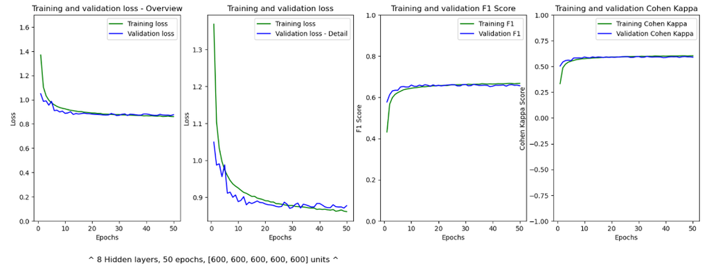

```python
from IPython.display import Image
Image(filename="./images/resultant_training_model.png", width='500')
```

The test loss, validation F1 Score, validation Cohen kappa seem to be relatively on par with the estimated model performance during training.

```python
stage_6_results.sort_values(by='val_f1_score', ascending=False).head()
```

|  | num_hidden_layers | num_units | optimizer | learning_rate | activation_function | batch_size | num_epochs | regularization | val_f1_score |
| --- | --- | --- | --- | --- | --- | --- | --- | --- | --- |
| 11 | 1 | 600 | rmsprop | 0.001 | relu | 128 | 100 | False | 0.702647 |
| 14 | 1 | 600 | rmsprop | 0.001 | relu | 128 | 100 | L2, alpha:1e-4 | 0.698807 |
| 25 | 4 | 600 | rmsprop | 0.001 | relu | 128 | 100 | False | 0.695391 |
| 19 | 4 | 600 | rmsprop | 0.001 | relu | 128 | 100 | L1, alpha:1e-4 | 0.689719 |
| 22 | 4 | 600 | rmsprop | 0.001 | relu | 128 | 100 | L2, alpha:1e-4 | 0.688726 |

Comparing the final model to the stage 6 and 7 results, there is a discrepancy of ~0.03 between validation f1 score and test f1 score. This seems a relatively small difference that suggests the validation evaluation procedure was functioning effectively.

```python
stage_5_results.shape[0] + stage_6_results.shape[0]
```

```
55
```

# Evaluation

'As a general guideline, an F1 score of 0.7 or higher is often considered good.' (Logunova & guide, 2023) - Based on this assessment is acceptable but could be improved:

#### Identifying areas for improvement:

I could further explore the application of L1 and L2 regularizers ; the Keras documentation that L1 and L2 can be supplied to the following parameters:

- kernel_regularizer: Regularizer to apply a penalty on the layer's kernel
- bias_regularizer: Regularizer to apply a penalty on the layer's bias
- activity_regularizer: Regularizer to apply a penalty on the layer's output

Source (Keras, 2024)

I think it would be beneficial to test a wider range of alpha values for L1 and L2 regularization. Part of the methodoloy of this coursework has been to identify optimal hyperparameters in isolation ; it may be more efficient to perform a grid search perhaps as the best performing model may require each hyperparameter to compromise / balance with the other hyperparameters.

I note that the TensorFlow library offers may learning rate schedulers, such as ExponentialDecay, CosineDecay etc - these are additional hyperparameter values for consideration.

Perhaps an alternative approach to hyperparameter tuning could be to retrieve a smaller stratified sample to perform a grid search; this could potentially establishing an initial search space in a relatively short amount of time (and in a systematic manner).

I would like to further explore the cause of performance plateau (eg perhaps a neural network 'saddle point').

#### Identifying areas for extension:

I am curious to investigate the importance of each hyperparameter for this dataset and model. An article published on website ‘Weights & Biases ‘ (an online applied machine learning community) discussed using random forests to calculate an ‘importance’ metric for each hyperparameter. (Shukla, 2023) The suggestion was that a random forest was passed hyperparameter values as inputs and the metric (eg loss) as the target output. Calculating an ’importance metric’ for each hyperparameter could reduce hyperparameter training time, with greater performance gains made in less time.  
This point is further expanded by (Coelho, 2020); 'For the most important hyperparameters we hope to reduce the search range and focus on the best values, while for the least important ones, we could fix them to a single value and thus remove entire dimensions from a grid search.'

I have recently read about neural network architectures that are designed to handle gradient-related problems (such as vanishing and exploding gradient). An example of this are ‘Residual connections’ ; these allow a network to ‘skip some layers and add the output of a previous layer to the input of a later layer. This can create a shortcut for the gradients to flow through the network and avoid being diluted by multiple layers.’ . By ‘skipping’ some layers a neural network can combine levels of abstraction; making it more capable of learning complex, non-linear patterns. (Cisco, 2023) Implementing techniques such as these could make for a more resilient model during training.

# Appendix A: Code to implement SMOTETomek

I chose to use a combination of SMOTE and Tomek Links as it effectively 'cleans' the dataset whilst oversampling (SMOTE) ; ambiguous points 'Tomek Links' are removed as part of the SMOTETomek process. (Truong, 2022)

I split the data into training, validation and test set before applying SMOTETomek, this decision was influenced by the following research; "If you are going to use SMOTE, it should only be applied to the training data. This is because you are using SMOTE to gain an improvement in operational performance, and both the validation and test sets are there to provide an estimate of operational performance" (Cawley, 2022)

For this reason I did not use the 'validation_split' parameter available for keras model.fit() https://keras.io/api/models/model_training_apis/

Random oversampling can decrease the variance of the dataset which can potentially lead to an overfitting model https://www.youtube.com/watch?v=8_4Ls7k1wyw Synthetic minority oversampling technique (SMOTE) developed by Chawla et al. (2002) - 'generates a new observation that exists on a line between observations' - there are 3 common extensions to SMOTE

Random undersampling can potentially remove key characteristics from the dataset https://www.youtube.com/watch?v=8_4Ls7k1wyw Tomek-links algorithm - 'takes 2 observations of different classes and whose distance is shortest using a form of k nearest neighbours - the algorithm then deletes the majority class observation'

the class imbalance suggests that accuracy is not an appropriate metric ; as a random model could potentially acheive a high accuracy by only predicting the majority class [https://machinelearningmastery.com/tour-of-evaluation-metrics-for-imbalanced-classification/]

for this reason I decided not to use the keras categorical_accuracy metric ; the keras documentation states that this metric 'Calculates how often predictions match one-hot labels' (Keras, 2024); if the validation/test set is imbalanced (ie with a majority class), a high accuracy could be acheived by a model that predicts the majority class every time.

I applied SMOTETomek to the training data ; this resulted in a balanced class distribution to train the model. However I did not apply SMOTETomek to the validation and testing data as it would have introduced artificial data (Nair, 2022) - this means that the validation and test sets are imbalanced. This imbalance affects the choice of evaluation metric:

My next step was to research evaluation metrics that are not impacted by class imbalance:

Candidates identified:

- F1 Score: appears to be appropraite for imbalanced datasets https://thedatascientist.com/f-1-measure-useful-imbalanced-class-problems/ 'Maximizing for the F1 score implies simultaneously maximizing for both precision and recall' (Logunova & guide, 2023)

a noted limitation of the F1 score is that it 'disregards true negatives, making it misleading for imbalanced classes' (Logunova & guide, 2023)

- Cohen Kappa ; 'normalized by the imbalance of the classes in the data.' (Brownlee, 2020) ; scores range from [-1, 1]. Negative scores indicate a disagreement between two raters; positive scores indicate agreement between. A score of 0 indicates agreement by chance. (TensorFlow, 2023)
- Area Under the Precision-Recall Curve (AUPRC) ; Machine learning researcher Daniel Rosenberg (MSc) suggested that AUPRC may offer a more accuracate performance estimate of models trained on imbalanced data (compared to ROC-AUC). Rosenberg attributes this to the difference in x-axis ; the ROC curve uses FPR (false positive rate), whilst AUPRC uses recall. In the context of unbalanced data, the rate of change of FPR is slower than recall. (Rosenberg, 2022)

```python
# from imblearn.combine import SMOTETomek
# from imblearn.under_sampling import TomekLinks
# #imblearn appears to be compatible with scikit-learn 1.2.2 - versions higher than this appear to be incompatible
# #as noted by other developers
# #https://stackoverflow.com/questions/76593906/how-to-resolve-cannot-import-name-missingvalues-from-sklearn-utils-param-v


# #this approach has been applied from
# #https://www.aitude.com/multiclass-classification-on-highly-imbalanced-dataset/
# resample=SMOTETomek(tomek=TomekLinks(sampling_strategy='majority'))
# x_train_SMOTETomek, y_train_SMOTETomek = resample.fit_resample(x_train, y_train)
```

```python
# y_train_SMOTETomek.hist()
```

```python
# from collections import Counter
# new_class_counts = Counter(y_train_SMOTETomek)
# min_class_count_ID = min(new_class_counts)
# percentage_of_dataset = new_class_counts[min_class_count_ID] / len(y_train_SMOTETomek) *100
# percentage_of_dataset
```

```python
# for key in new_class_counts:
#     print(new_class_counts[key] / len(y_train_SMOTETomek) *100)
```

### A graph of the samples generated by SMOTE (shown in green):

```python
# import matplotlib.pyplot as plt

# classes = list(set(y))

# plt.bar(classes, height=y.value_counts().to_list(), color='cornflowerblue')
# plt.bar(classes, height=y_train_SMOTETomek.value_counts().to_list(), color='lime')
# plt.show()
```

```python
# plt.scatter(x_train_SMOTETomek['channel2'], y_train_SMOTETomek, s=10, c='lime', marker="s", label='SMOTE-generated')
# plt.scatter(x_train['channel2'], y_train, s=10, c='b', marker="s", label='original')
# plt.legend(loc='upper left')
# plt.show()
```

### Scaling on SMOTETomek Data

```python
# from sklearn.preprocessing import MinMaxScaler
# #scaler = MinMaxScaler(feature_range=(-1, 1))
# scaler = MinMaxScaler()
# x_train_SMOTETomek_scaled = scaler.fit_transform(x_train_SMOTETomek)
# x_train_SMOTETomek_scaled
```

### Convert to SMOTETomek data to tensor form

```python
# import tensorflow as tf
# #The DataFrame can be converted to a NumPy array using the DataFrame.values property or numpy.array(df).
# #To convert it to a tensor, use tf.convert_to_tensor:
# #https://www.tensorflow.org/tutorials/load_data/pandas_dataframe
# x_train_SMOTETomek_scaled = tf.convert_to_tensor(x_train_SMOTETomek_scaled)
# x_train_SMOTETomek_scaled
```

### One hot encode SMOTETomek data

```python
# new_SMOTETomek_train_classes = [x-1 for x in list(y_train_SMOTETomek)]
```

```python
# y_train = to_categorical(new_SMOTETomek_train_classes)
# y_train_SMOTETomek = tf.convert_to_tensor(y_train)
# y_train_SMOTETomek
```

### Calcuation of majority class baseline on SMOTETomek data

```python
# SMOTETomek_class_count = Counter(new_SMOTETomek_train_classes)
# SMOTETomek_class_count
```

```python
# max_class_ID_SMOTETomek = max(SMOTETomek_class_count)
# max_class_count_SMOTETomek = SMOTETomek_class_count[max_class_ID_SMOTETomek]
# total_class_count_SMOTETomek = len(y_train_SMOTETomek)
# statistical_baseline_SMOTETomek = max_class_count_SMOTETomek / total_class_count_SMOTETomek * 100
# statistical_baseline_SMOTETomek
```

On reflection and further research I realised that the above was not directly comparabale to the F1 evaluation of the model; Further research identified that the common sense baseline is calculated on the test set (Brownlee, 2020)

With this in mind; I calculated the following common sense baseline:

```python
# #majority class baseline: f1 score
# from sklearn.dummy import DummyClassifier
# from sklearn.metrics import classification_report
# from sklearn.metrics import precision_recall_fscore_support as score

# dummy_clf = DummyClassifier(strategy="most_frequent")
# dummy_clf.fit(x_train_SMOTETomek_scaled, y_train_SMOTETomek)
# y_pred_dummy = dummy_clf.predict(x_test)
# precision,recall,fscore,support=score(y_test,y_pred_dummy,average='macro')
# fscore
```

```python
# #random baseline: calculated on validation data
# dummy_clf = DummyClassifier(strategy="uniform")
# #the sklearn docs define 'uniform' as follows:
# #'generates predictions uniformly at random from the list of unique classes observed in y, i.e. each class has equal probability.'
# #(scikit learn, 2024)
# dummy_clf.fit(x_train_SMOTETomek_scaled, y_train_SMOTETomek)
# y_pred_dummy = dummy_clf.predict(x_val)
# precision,recall,fscore,support=score(y_val,y_pred_dummy,average='macro')
# val_common_sense_baseline = fscore
# val_common_sense_baseline
```

```python
# #random baseline: calculated on test data
# dummy_clf = DummyClassifier(strategy="uniform")
# #the sklearn docs define 'uniform' as follows:
# #'generates predictions uniformly at random from the list of unique classes observed in y, i.e. each class has equal probability.'
# #(scikit learn, 2024)
# dummy_clf.fit(x_train_SMOTETomek_scaled, y_train_SMOTETomek)
# y_pred_dummy = dummy_clf.predict(x_test)
# precision,recall,fscore,support=score(y_test,y_pred_dummy,average='macro')
# test_common_sense_baseline = fscore
# test_common_sense_baseline
```

### Train the model on SMOTETomek data

```python
# initial_hyperparameters = {
#             "optimizer": 'rmsprop',
#             "learning_rate": None,
#             "batch_size": 128,
#             "epochs_number": 5,
#             "loss_function": 'categorical_crossentropy',
#             #use categorical cross entropy as targets are one-hot encoded
#         }
# initial_layers = [
#     layers.Dense(10, activation='relu', input_shape=(9,)), #input shape == x_train_tensor[0].shape
#     layers.Dense(num_classes, activation='softmax') #7 output neurons as there are 7 classes
#     ]

# model_1 = NeuralNet(initial_layers)
# model_1.set_hyperparameters(initial_hyperparameters)
# model_1.compile_model()
# model_1.fit(x_train_SMOTETomek_scaled, y_train_SMOTETomek, (x_val_scaled, y_val))
```

# Appendix B: Comparing the performance of a model trained on non-SMOTETomek data

### Model definition 2: Trained on non-SMOTETomek Data

### (compare to the model trained on SMOTETomek data)

```python
# model_2 = NeuralNet(initial_layers)
# model_2.set_hyperparameters(initial_hyperparameters)
# model_2.compile_model()
# model_2.fit(x_train_scaled, y_train, (x_val_scaled, y_val))
```

[figure not shown]

Image source: (Bhattiprolu, 2020)

# References

Arie, B. D. (2008, January 6). Comparison of classification accuracy using Cohen’s Weighted Kappa. Science Direct. Retrieved March 11, 2024, from https://www.sciencedirect.com/science/article/abs/pii/S0957417406003435

Awan, A. A. (2023). What is Online Machine Learning? DataCamp. Retrieved March 10, 2024, from https://www.datacamp.com/blog/what-is-online-machine-learning

Bhattiprolu, S. (2020, September 1). 154 - Understanding the training and validation loss curves. Wikipedia. Retrieved March 6, 2024, from https://www.youtube.com/watch?v=p3CcfIjycBA&t=666s

Brownlee, J. (2019, August 6). How to use Learning Curves to Diagnose Machine Learning Model Performance - MachineLearningMastery.com. Machine Learning Mastery. Retrieved March 7, 2024, from https://machinelearningmastery.com/learning-curves-for-diagnosing-machine-learning-model-performance/

Brownlee, J. (2020, Jan 2). How To Get Baseline Results And Why They Matter - MachineLearningMastery.com. Machine Learning Mastery. Retrieved March 6, 2024, from https://machinelearningmastery.com/how-to-get-baseline-results-and-why-they-matter/

Brownlee, J. (2020, August 15). 8 Tactics to Combat Imbalanced Classes in Your Machine Learning Dataset - MachineLearningMastery.com. Machine Learning Mastery. Retrieved March 6, 2024, from https://machinelearningmastery.com/tactics-to-combat-imbalanced-classes-in-your-machine-learning-dataset/

Brownlee, J. (2021, January 22). How to Choose an Activation Function for Deep Learning - MachineLearningMastery.com. Machine Learning Mastery. Retrieved March 7, 2024, from https://machinelearningmastery.com/choose-an-activation-function-for-deep-learning/

Brownlee, J. (2021, May 1). Tour of Evaluation Metrics for Imbalanced Classification - MachineLearningMastery.com. Machine Learning Mastery. Retrieved March 11, 2024, from https://machinelearningmastery.com/tour-of-evaluation-metrics-for-imbalanced-classification/

Buhl, N. (2023, July 18). F1 Score in Machine Learning Explained. Encord. Retrieved March 6, 2024, from https://encord.com/blog/f1-score-in-machine-learning/

Cawley, G. C. (2022, January 13). How to use SMOTE on the final model training? Cross Validated. Retrieved March 4, 2024, from https://stats.stackexchange.com/questions/560321/how-to-use-smote-on-the-final-model-training

Ch, V. (2023, July 13). What unit should I put for my Dense? TensorFlow Forum. Retrieved March 8, 2024, from https://discuss.tensorflow.org/t/what-unit-should-i-put-for-my-dense/18173/2

Chollet, F. (2018). Deep Learning with Python. Manning. https://livebook.manning.com/book/deep-learning-with-python/chapter-3/163

Cisco. (2023, November 27). How to Prevent Vanishing Gradients in Neural Networks. LinkedIn. Retrieved March 11, 2024, from https://www.linkedin.com/advice/3/what-best-practices-preventing-vanishing-bmaef

Coelho, A. (2020, June 17). Narrowing the Search: Which Hyperparameters Really Matter? Dataiku blog. Retrieved March 11, 2024, from https://blog.dataiku.com/narrowing-the-search-which-hyperparameters-really-matter

Shukla, L. (2023, September 18). Find The Most Important Hyperparameters In Seconds | articles – Weights & Biases. Weights & Biases. Retrieved March 11, 2024, from https://wandb.ai/wandb_fc/articles/reports/Find-The-Most-Important-Hyperparameters-In-Seconds--Vmlldzo1NDMxNTQz

Crêteur, S. (2022, December 16). Machine learning: one-hot encoding vs integer encoding | by Stéphanie Crêteur | Geek Culture. Medium. Retrieved March 10, 2024, from https://medium.com/geekculture/machine-learning-one-hot-encoding-vs-integer-encoding-f180eb831cf1

Cisco. (2023, November 27). How to Prevent Vanishing Gradients in Neural Networks. LinkedIn. Retrieved March 11, 2024, from https://www.linkedin.com/advice/3/what-best-practices-preventing-vanishing-bmaef

DeepLearningAI & Andrew, N. (2017, August 25). The Problem of Local Optima (C2W3L10). YouTube. Retrieved March 11, 2024, from https://www.youtube.com/watch?v=fODpu1-lNTw

Engati. (2024). Vanishing gradient problem | Engati. Engati chatbot. Retrieved March 7, 2024, from https://www.engati.com/glossary/vanishing-gradient-problem

Google. (2023, June 9). Imbalanced Data | Machine Learning. Google for Developers. Retrieved March 6, 2024, from https://developers.google.com/machine-learning/data-prep/construct/sampling-splitting/imbalanced-data

iguazio. (2024). What is Baseline Models. Iguazio. Retrieved March 6, 2024, from https://www.iguazio.com/glossary/baseline-models/ John Hopkins Medicine. (2024). Electromyography (EMG). Johns Hopkins Medicine. Retrieved March 10, 2024, from https://www.hopkinsmedicine.org/health/treatment-tests-and-therapies/electromyography-emg

Katanforoosh, K. (2019). Initializing neural networks - deeplearning.ai. DeepLearning.AI. Retrieved March 11, 2024, from https://www.deeplearning.ai/ai-notes/initialization/index.html

Keras. (2024). Accuracy metrics. Keras. Retrieved March 6, 2024, from https://keras.io/api/metrics/accuracy_metrics/#categoricalaccuracy-class

Keras. (2024). Layer weight regularizers. Keras. Retrieved March 11, 2024, from https://keras.io/api/layers/regularizers/

Logunova, I., & guide, s. (2023, July 10). F1 Score in Machine Learning. Serokell. Retrieved March 5, 2024, from https://serokell.io/blog/a-guide-to-f1-score#

Mayank, K. (2023, April 4). BxD Primer Series: Elastic Net Regression; combining L1 and L2 regularization. LinkedIn. Retrieved March 11, 2024, from https://www.linkedin.com/pulse/bxd-primer-series-elastic-net-regression-combining-l1-mayank-k-

McGill, S. (1999, September 22). The importance of normalization in the interpretation of surface electromyography: a proof of principle. PubMed. Retrieved February 23, 2024, from https://pubmed.ncbi.nlm.nih.gov/10519560/

Mohd, F. (2006). Techniques of EMG signal analysis: detection, processing, classification and applications. NCBI. Retrieved March 10, 2024, from https://www.ncbi.nlm.nih.gov/pmc/articles/PMC1455479/

Morgunov, A. (2023, August 23). Keras Tuner: Lessons Learned From Tuning Hyperparameters of a Real-Life Deep Learning Model. neptune.ai. Retrieved March 8, 2024, from https://neptune.ai/blog/keras-tuner-tuning-hyperparameters-deep-learning-model

Nair, A. (2022, January 24). Create Artificial Data With SMOTE | by Aashish Nair. Towards Data Science. Retrieved March 6, 2024, from https://towardsdatascience.com/create-artificial-data-with-smote-2a31ee855904

Pao, S. (2021, April 11). Sampling Data with SMOTE, Tomek Links, and Nearmiss in R. YouTube. Retrieved February 22, 2024, from https://www.youtube.com/watch?v=8_4Ls7k1wyw

Rosebrock, A. (2019, October 14). Why is my validation loss lower than my training loss? PyImageSearch. Retrieved March 10, 2024, from https://pyimagesearch.com/2019/10/14/why-is-my-validation-loss-lower-than-my-training-loss/

Rosenberg, D. (2022, June 6). Imbalanced Data? Stop Using ROC-AUC and Use AUPRC Instead. Towards Data Science. Retrieved February 22, 2024, from https://towardsdatascience.com/imbalanced-data-stop-using-roc-auc-and-use-auprc-instead-46af4910a494

Saturn Cloud. (2023, July 6). What Is 'random_state' in sklearn.model_selection.train_test_split Example? Saturn Cloud. Retrieved March 5, 2024, from https://saturncloud.io/blog/what-is-randomstate-in-sklearnmodelselectiontraintestsplit-example/

scikit learn. (2024). sklearn.dummy.DummyClassifier — scikit-learn 1.4.1 documentation. Scikit-learn. Retrieved March 6, 2024, from https://scikit-learn.org/stable/modules/generated/sklearn.dummy.DummyClassifier.html

TensorFlow. (2023, May 25). tfa.metrics.CohenKappa. TensorFlow. Retrieved March 6, 2024, from https://www.tensorflow.org/addons/api_docs/python/tfa/metrics/CohenKappa

Truong, A. (2022, June 27). Imbalanced Data ML: SMOTE and its variants | by An Truong | TotalEnergies Digital Factory. Medium. Retrieved March 10, 2024, from https://medium.com/totalenergies-digital-factory/imbalanced-data-ml-smote-and-its-variants-c69a4b32f7e7

Turp, M. (2022, Nov). How to Make Neural Networks Train Faster on Keras. YouTube: Home. Retrieved March 10, 2024, from https://www.youtube.com/watch?v=NBhas7xb3h4&t=304s

Turp, M. (2022, November 9). How to Choose an Activation Function for Neural Networks. YouTube. Retrieved March 8, 2024, from https://www.youtube.com/watch?v=_UjA9sk_fK4

UC Irvine Machine Learning Repository. (2019, June 1). EMG data for gestures. UCI Machine Learning Repository. Retrieved March 10, 2024, from https://archive.ics.uci.edu/dataset/481/emg+data+for+gestures

Wang, A. (2022, August 5). Why Using Learning Rate Schedulers In NNs May Be a Waste of Time. Towards Data Science. Retrieved March 10, 2024, from https://towardsdatascience.com/why-using-learning-rate-schedulers-in-nns-may-be-a-waste-of-time-8fa20339002b

Wang, C.-F. (2019, January 8). The Vanishing Gradient Problem. The Problem, Its Causes, Its… | by Chi-Feng Wang. Towards Data Science. Retrieved March 7, 2024, from https://towardsdatascience.com/the-vanishing-gradient-problem-69bf08b15484